# Assignment

## Models

```python
X = df_upsampled.drop(columns='RainTomorrow')
y = df_upsampled['RainTomorrow']
```

```python
X_train, X_test, y_train, y_test = train_test_split(X, y, train_size=0.9, shuffle=True, random_state=44)
```

```python
RandomForestClassifierModel = RandomForestClassifier(criterion = 'gini', max_depth=17, n_estimators=100, random_state=44)
RandomForestClassifierModel.fit(X_train, y_train)


print('RandomForestClassifierModel Train Score is : ' , RandomForestClassifierModel.score(X_train, y_train))
print('RandomForestClassifierModel Test Score is : ' , RandomForestClassifierModel.score(X_test, y_test))
```

```
RandomForestClassifierModel Train Score is :  0.9804006278711425
RandomForestClassifierModel Test Score is :  0.9274235355106273
```

```python
from sklearn.metrics import f1_score, accuracy_score

# Predict labels for training and test sets
y_train_pred = RandomForestClassifierModel.predict(X_train)
y_test_pred = RandomForestClassifierModel.predict(X_test)

# Calculate F1 score
f1 = f1_score(y_test, y_test_pred)
print('F1 Score:', f1)

# Calculate accuracy
accuracy = accuracy_score(y_test, y_test_pred)
print('Accuracy:', accuracy)
```

```
F1 Score: 0.9293464547060308
Accuracy: 0.9274235355106273
```

```python
import joblib
from sklearn.ensemble import RandomForestClassifier

# Build and train your model
# fit your model on training data

# Save your trained model
joblib.dump(RandomForestClassifierModel, 'RandomForestClassifierModel.joblib')
```

```
['RandomForestClassifierModel.joblib']
```

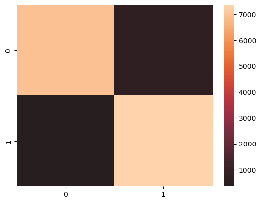

```
Confusion Matrix is
 [[6946  763]
 [ 357 7366]]
```

```python
y_pred_RF = RandomForestClassifierModel.predict(X_test)
CM_RF = confusion_matrix(y_test, y_pred_RF)

sns.heatmap(CM_RF, center=True)
plt.show()

print('Confusion Matrix is\n', CM_RF)
```

```python
GBCModel = GradientBoostingClassifier(n_estimators=200, max_depth=11, learning_rate=0.07, random_state=44)
GBCModel.fit(X_train, y_train)
print('GBCModel Train Score is : ' , GBCModel.score(X_train, y_train))
print('GBCModel Test Score is : ' , GBCModel.score(X_test, y_test))
```

```
GBCModel Train Score is :  0.9900923085785055
GBCModel Test Score is :  0.9331907724209435
```

```python
from sklearn.ensemble import GradientBoostingClassifier
from sklearn.metrics import f1_score, accuracy_score
from sklearn.model_selection import train_test_split

X = df_upsampled.drop(columns='RainTomorrow')
y = df_upsampled['RainTomorrow']
X_train, X_test, y_train, y_test = train_test_split(X, y, train_size=0.9, shuffle=True, random_state=44)

GradientBoostingClassifierModel = GradientBoostingClassifier(n_estimators=200, max_depth=11, learning_rate=0.07, random_state=44)
GradientBoostingClassifierModel.fit(X_train, y_train)
```

```
GradientBoostingClassifier(learning_rate=0.07, max_depth=11, n_estimators=200,
                           random_state=44)
```

```python
print('GBCModel Train Score is : ' , GBCModel.score(X_train, y_train))
print('GBCModel Test Score is : ' , GBCModel.score(X_test, y_test))
# Predict labels for training and test sets
y_train_pred = GradientBoostingClassifierModel.predict(X_train)
y_test_pred = GradientBoostingClassifierModel.predict(X_test)

# Calculate F1 score
f1 = f1_score(y_test, y_test_pred)
print('F1 Score:', f1)

# Calculate accuracy
accuracy = accuracy_score(y_test, y_test_pred)
print('Accuracy:', accuracy)
```

```
GBCModel Train Score is :  0.9900923085785055
GBCModel Test Score is :  0.9331907724209435
F1 Score: 0.93528340970435
Accuracy: 0.9331907724209435
```

```python
joblib.dump(GBCModel, 'GBCModel.joblib')
```

```
['GBCModel.joblib']
```

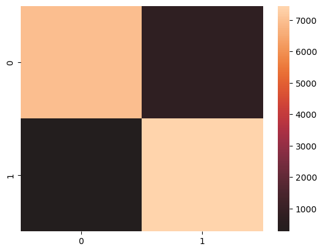

```
Confusion Matrix is
 [[6951  758]
 [ 273 7450]]
```

```python
y_pred_GB = GBCModel.predict(X_test)
CM_GB = confusion_matrix(y_test, y_pred_GB)

sns.heatmap(CM_GB, center=True)
plt.show()

print('Confusion Matrix is\n', CM_GB)
```

```python
y_pred = GBCModel.predict(test)
```

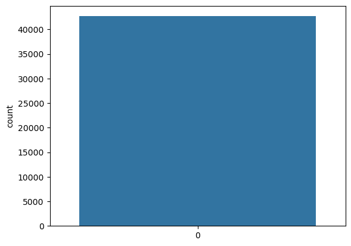

```python
sns.countplot(y_pred)
```

```python
test = pd.read_csv('WeatherTestData.csv')
submission = test[["row ID"]]
submission["RainTomorrow"] = y_pred
```

```python
submission.to_csv('predict_weather.csv', index=False)
```

Two different testing algorithms that we use:

1. Randomized Search Cross Validation for Hyperparameter Tuning: This algorithm randomly selects a set of hyperparameters and uses cross-validation to evaluate the model's performance. It then repeats this process multiple times and selects the best set of hyperparameters that give the highest accuracy score.

```python
from sklearn.model_selection import RandomizedSearchCV

# define the hyperparameter grid
param_grid = {
    'n_estimators': [100, 200, 300],
    'max_features': ['auto', 'sqrt'],
    'max_depth': [5, 10, 15, None],
    'min_samples_split': [2, 5, 10],
    'min_samples_leaf': [1, 2, 4]
}

# create a Random Forest Classifier object
rfc = RandomForestClassifier(random_state=42)

# create a RandomizedSearchCV object
rscv = RandomizedSearchCV(
    estimator=rfc, param_distributions=param_grid,
    n_iter=10, cv=5, verbose=2, random_state=42, n_jobs=-1
)

# fit the RandomizedSearchCV object on the training data
rscv.fit(X_train, y_train)

# print the best hyperparameters and the corresponding accuracy score
print("Best Hyperparameters:", rscv.best_params_)
print("Best Accuracy Score:", rscv.best_score_)

# evaluate the model on the test data
rfc_best = rscv.best_estimator_
print("Test Accuracy Score:", rfc_best.score(X_test, y_test))

joblib.dump(rfc, 'rfc.joblib')
```

[output not shown]

[output not shown]

[output not shown]

[output not shown]

[output not shown]

[output not shown]

[output not shown]

[output not shown]

[output not shown]

[output not shown]

[output not shown]

[output not shown]

[output not shown]

[output not shown]

[output not shown]

[output not shown]

[output not shown]

[output not shown]

[output not shown]

```
[CV] END max_depth=10, max_features=auto, min_samples_leaf=4, min_samples_split=2, n_estimators=200; total time=  24.0s
[CV] END max_depth=10, max_features=auto, min_samples_leaf=4, min_samples_split=2, n_estimators=200; total time=  24.1s
[CV] END max_depth=None, max_features=auto, min_samples_leaf=4, min_samples_split=2, n_estimators=300; total time=  56.8s
[CV] END max_depth=None, max_features=auto, min_samples_leaf=4, min_samples_split=2, n_estimators=300; total time=  57.1s
[CV] END max_depth=None, max_features=auto, min_samples_leaf=4, min_samples_split=2, n_estimators=300; total time=  57.1s
[CV] END max_depth=10, max_features=auto, min_samples_leaf=4, min_samples_split=2, n_estimators=200; total time=  24.4s
[CV] END max_depth=None, max_features=auto, min_samples_leaf=4, min_samples_split=2, n_estimators=300; total time=  56.8s
[CV] END max_depth=None, max_features=auto, min_samples_leaf=4, min_samples_split=2, n_estimators=300; total time=  56.6s
[CV] END max_depth=None, max_features=sqrt, min_samples_leaf=2, min_samples_split=10, n_estimators=200; total time=  38.0s
[CV] END max_depth=None, max_features=sqrt, min_samples_leaf=2, min_samples_split=10, n_estimators=200; total time=  37.7s
[CV] END max_depth=None, max_features=sqrt, min_samples_leaf=2, min_samples_split=10, n_estimators=200; total time=  37.9s
[CV] END max_depth=None, max_features=sqrt, min_samples_leaf=2, min_samples_split=10, n_estimators=200; total time=  38.1s
[CV] END max_depth=15, max_features=sqrt, min_samples_leaf=1, min_samples_split=5, n_estimators=200; total time=  33.3s
[CV] END max_depth=None, max_features=sqrt, min_samples_leaf=2, min_samples_split=10, n_estimators=200; total time=  37.8s
[CV] END max_depth=15, max_features=sqrt, min_samples_leaf=1, min_samples_split=5, n_estimators=200; total time=  33.7s
[CV] END max_depth=15, max_features=sqrt, min_samples_leaf=1, min_samples_split=5, n_estimators=200; total time=  33.7s
[CV] END max_depth=15, max_features=sqrt, min_samples_leaf=1, min_samples_split=5, n_estimators=200; total time=  30.0s
[CV] END max_depth=15, max_features=sqrt, min_samples_leaf=1, min_samples_split=5, n_estimators=200; total time=  26.7s
Best Hyperparameters: {'n_estimators': 100, 'min_samples_split': 5, 'min_samples_leaf': 2, 'max_features': 'sqrt', 'max_depth': None}
Best Accuracy Score: 0.9268227680017898
Test Accuracy Score: 0.9444660445826853
```

```
['rfc.joblib']
```

1. Receiver Operating Characteristic (ROC) Curve: This algorithm is used to evaluate the performance of a binary classifier at different classification thresholds. It plots the True Positive Rate (TPR) against the False Positive Rate (FPR) for different threshold values. The area under the ROC curve (AUC-ROC) is a performance metric that ranges from 0.5 to 1. A higher AUC-ROC indicates better model performance.

```
['gbc.joblib']
```

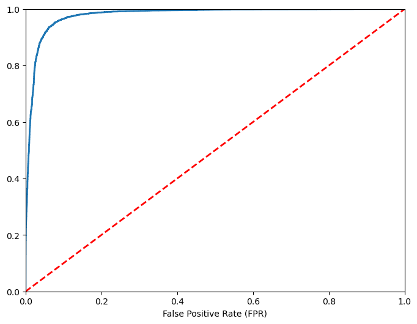

```python
from sklearn.metrics import roc_curve, auc

# fit the Gradient Boosting Classifier on the training data
gbc = GradientBoostingClassifier(n_estimators=200, max_depth=11, learning_rate=0.07, random_state=44)
gbc.fit(X_train, y_train)

# predict the probabilities of the positive class for the test data
y_proba = gbc.predict_proba(X_test)[:, 1]

# calculate the False Positive Rate (FPR), True Positive Rate (TPR), and threshold values
fpr, tpr, thresholds = roc_curve(y_test, y_proba)

# calculate the Area Under the Curve (AUC-ROC)
auc_roc = auc(fpr, tpr)

# plot the ROC curve
plt.figure(figsize=(8, 6))
plt.plot(fpr, tpr, lw=2, label=f'AUC = {auc_roc:.2f}')
plt.plot([0, 1], [0, 1], linestyle='--', lw=2, color='r', label='Random Guess')
plt.xlim([0.0, 1.0])
plt.ylim([0.0, 1.0])
plt.xlabel('False Positive Rate (FPR)')

joblib.dump(gbc, 'gbc.joblib')
```

```python
print(fpr, tpr)
```

```
[0.         0.         0.         ... 0.87624854 0.87624854 1.        ] [0.00000000e+00 1.29483361e-04 6.47416807e-04 ... 9.99870517e-01
 1.00000000e+00 1.00000000e+00]
```

The DummyClassifier in scikit-learn does not require explicit training or fitting since it employs simple rules for prediction based on the specified strategy. The strategy='most_frequent' strategy used in your code instructs the DummyClassifier to always predict the most frequent class in the training data. Hence, the model does not learn from the data during training.

DummyClassifier from scikit-learn, which provides a simple strategy for generating predictions.

```
DummyClassifier Test Score is :  0.49954639709694143
```

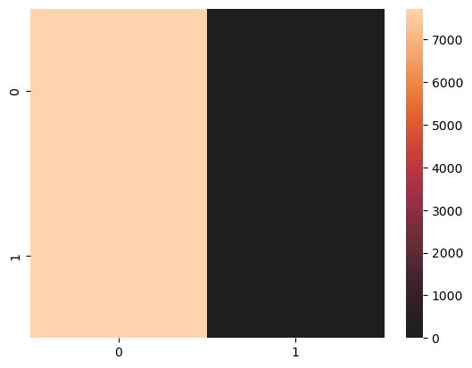

```
Confusion Matrix is
 [[7709    0]
 [7723    0]]
```

```python
# import necessary modules
from sklearn.dummy import DummyClassifier
from sklearn.metrics import confusion_matrix
import seaborn as sns
import matplotlib.pyplot as plt

# create a new instance of the classifier
dummy = DummyClassifier(strategy='most_frequent')

# fit the model on the training data
dummy.fit(X_train, y_train)

# predict on the test data
y_pred_dummy = dummy.predict(X_test)

# evaluate the model
print('DummyClassifier Test Score is : ', dummy.score(X_test, y_test))

# calculate and print the confusion matrix
CM_dummy = confusion_matrix(y_test, y_pred_dummy)
sns.heatmap(CM_dummy, center=True)
plt.show()
print('Confusion Matrix is\n', CM_dummy)
```

```python
'''import statistics

# list of positive integer numbers
MinTemp = data_test['MinTemp']
MaxTemp = data_test['MaxTemp']
Rainfall= data_test['Rainfall']
WindGustSpeed= data_test['WindGustSpeed']
WindSpeed9am= data_test['WindSpeed9am']
WindSpeed3pm= data_test['WindSpeed3pm']
Humidity9am= data_test['Humidity9am']
Humidity3pm= data_test['Humidity3pm']
Pressure9am= data_test['Pressure9am']
Pressure3pm= data_test['Pressure3pm']
Cloud9am =  data_test['Cloud9am']
Cloud3pm = data_test['Cloud3pm']
Temp9am = data_test['Temp9am']
Temp3pm = data_test['Temp3pm']
RainToday = data_test['RainToday']

MinTemp_mean = statistics.mean(MinTemp)
MaxTemp_mean = statistics.mean(MaxTemp)
Rainfall_mean = statistics.mean(Rainfall)
WindGustSpeed_mean = statistics.mean(WindGustSpeed)
WindSpeed9am_mean = statistics.mean(WindSpeed9am)
WindSpeed3pm_mean = statistics.mean(WindSpeed3pm)
Humidity9am_mean = statistics.mean(Humidity9am)
Humidity3pm_mean = statistics.mean(Humidity3pm)
Pressure9am_mean = statistics.mean(Pressure9am)
Pressure3pm_mean = statistics.mean(Pressure3pm)
Cloud9am_mean  = statistics.mean(Cloud9am)
Cloud3pm_mean  = statistics.mean(Cloud3pm)
Temp9am_mean   = statistics.mean(Temp9am)
Temp3pm_mean = statistics.mean(Temp3pm)


# Printing the mean
print("MinTemp Mean is :", MinTemp_mean)
print("MaxTemp Mean is :", MaxTemp_mean)
print("Rainfall Mean is :", Rainfall_mean)
print("WindGustSpeed Mean is :", WindGustSpeed_mean)
print("WindSpeed9am Mean is :", WindSpeed9am_mean)
print("WindSpeed3pm Mean is :", WindSpeed3pm_mean)
print("Humidity9am Mean is :", Humidity9am_mean)
print("Humidity3pm Mean is :", Humidity3pm_mean)
print("Pressure9am Mean is :", Pressure9am_mean)
print("Pressure3pm Mean is :", Pressure3pm_mean)
print("Cloud9am Mean is :", Cloud9am_mean)
print("Cloud3pm Mean is :", Cloud3pm_mean)
print("Cloud3pm Mean is :", Cloud3pm_mean)
print("Temp9am Mean is :", Temp9am_mean)
print("Temp3pm Mean is :", Temp3pm_mean)

MinTemp_standard_deviation = statistics.stdev(MinTemp)
MaxTemp_standard_deviation  = statistics.stdev(MaxTemp)
Rainfall_standard_deviation  = statistics.stdev(Rainfall)
WindGustSpeed_standard_deviation  = statistics.stdev(WindGustSpeed)
WindSpeed9am_standard_deviation  = statistics.stdev(WindSpeed9am)
WindSpeed3pm_standard_deviation  = statistics.stdev(WindSpeed3pm)
Humidity9am_standard_deviation  = statistics.stdev(Humidity9am)
Humidity3pm_standard_deviation = statistics.stdev(Humidity3pm)
Pressure9am_standard_deviation  = statistics.stdev(Pressure9am)
Pressure3pm_standard_deviation  = statistics.stdev(Pressure3pm)
Cloud9am_standard_deviation   = statistics.stdev(Cloud9am)
Cloud3pm_standard_deviation  = statistics.stdev(Cloud3pm)
Temp9am_standard_deviation   = statistics.stdev(Temp9am)
Temp3pm_standard_deviation  = statistics.stdev(Temp3pm)


print("Standard Deviation of the MaxTemp is % s "%(statistics.stdev(MinTemp)))
print("Standard Deviation of the MaxTemp is % s "%(statistics.stdev(MaxTemp)))
print("Standard Deviation of the Rainfall is:", Rainfall_standard_deviation)
print("Standard Deviation of the WindGustSpeed is:",WindGustSpeed_standard_deviation)
print("Standard Deviation of the WindSpeed9am is:", WindSpeed9am_standard_deviation)
print("Standard Deviation of the WindSpeed3pm is:",WindSpeed3pm_standard_deviation)
print("Standard Deviation of the Humidity9am is:", Humidity9am_standard_deviation)
print("Standard Deviation of the Humidity3pm is:", Humidity3pm_standard_deviation)
print("Standard Deviation of the Pressure9am is:",Pressure9am_standard_deviation)
print("Standard Deviation of the Pressure3pm is:",Pressure3pm_standard_deviation)
print("Standard Deviation of the Cloud9am is:", Cloud9am_standard_deviation)
print("Standard Deviation of the Cloud3pm is:", Cloud3pm_standard_deviation)
print("Standard Deviation of the Temp9am is:", Temp9am_standard_deviation)
print("Standard Deviation of the Temp3pm is:",Temp3pm_standard_deviation)

import scipy.stats as stats

# stats f_oneway functions takes the groups as input and returns ANOVA F and p value
fvalue= stats.f_oneway(data_test['MinTemp'], data_test['MaxTemp'],data_test['Rainfall'], data_test['WindGustSpeed'],data_test['WindSpeed9am'],data_test['WindSpeed3pm'],data_test['Humidity9am'],data_test['Humidity3pm'],data_test['Pressure9am'],data_test['Pressure3pm'],data_test['Cloud9am'],data_test['Cloud3pm'], data_test['Temp9am'],data_test['Temp3pm'])
pvalue = stats.f_oneway(data_test['MinTemp'], data_test['MaxTemp'],data_test['Rainfall'], data_test['WindGustSpeed'],data_test['WindSpeed9am'],data_test['WindSpeed3pm'],data_test['Humidity9am'],data_test['Humidity3pm'],data_test['Pressure9am'],data_test['Pressure3pm'],data_test['Cloud9am'],data_test['Cloud3pm'], data_test['Temp9am'],data_test['Temp3pm'])

#print(fvalue, pvalue)
print("The result of Anova test is:",fvalue)
print("The result of p vaue is:",pvalue)

#kruskal's test
result = stats.kruskal(data_test['MinTemp'], data_test['MaxTemp'],data_test['Rainfall'], data_test['WindGustSpeed'],data_test['WindSpeed9am'],data_test['WindSpeed3pm'],data_test['Humidity9am'],data_test['Humidity3pm'],data_test['Pressure9am'],data_test['Pressure3pm'],data_test['Cloud9am'],data_test['Cloud3pm'], data_test['Temp9am'],data_test['Temp3pm'])

# Print the result
print(result)


import statsmodels.api as sm
from statsmodels.formula.api import ols

#perform two-way ANOVA
model = ols('RainToday ~ MinTemp + MaxTemp + Rainfall + WindGustSpeed +WindSpeed9am +WindSpeed3pm +Humidity9am +Humidity3pm +Pressure9am +Pressure3pm +Cloud9am +Cloud3pm +Temp9am +Temp3pm', data=data_test).fit()
sm.stats.anova_lm(model, typ=2)

model = ols("""height ~ C(program) + C(gender) + C(division) +
               C(program):C(gender) + C(program):C(division) + C(gender):C(division) +
               C(program):C(gender):C(division)""", data=df).fit()

sm.stats.anova_lm(model, typ=2)'''
```

[output not shown]